# Merging data & plotting models

### LM with an interaction effect

Then, let’s make a model with an interaction between work ethic and gender. We can see that the coefficients for the intercept and main effect have changed.

```r
summary(GPA.Model.2)
```

```
Call:
lm(formula = GPA ~ Work_Ethic * Gender, data = GPA_data)

Residuals:
     Min       1Q   Median       3Q      Max
-1.35807 -0.36015  0.00458  0.32260  1.12149

Coefficients:
                        Estimate Std. Error t value Pr(>|t|)
(Intercept)              0.98106    0.20466   4.794 3.23e-06 ***
Work_Ethic               0.13972    0.06958   2.008  0.04602 *
GenderFemale             0.69482    0.26672   2.605  0.00989 **
Work_Ethic:GenderFemale  0.23580    0.09264   2.545  0.01169 *
---
Signif. codes:  0 ‘***’ 0.001 ‘**’ 0.01 ‘*’ 0.05 ‘.’ 0.1 ‘ ’ 1

Residual standard error: 0.4701 on 196 degrees of freedom
Multiple R-squared:  0.6856,    Adjusted R-squared:  0.6808
F-statistic: 142.5 on 3 and 196 DF,  p-value: < 2.2e-16
```

This time, we’ll use broom::augment() to predict the values, but add the annotations manually. Note that we can use the exact same chunk of code when plotting the annotations (with the addition of interaction) - it works because we’re extracting the coefficients from the model fit, not just typing in the coefficient values.

| GPA | Work_Ethic | Gender | .fitted | .se.fit | .resid | .std.resid | .hat | .sigma | .cooksd | Intercept | Female_coef | Work_ethic_coef | interaction_coef | Female_coef_arrow | interaction_coef_arrow |
| --- | --- | --- | --- | --- | --- | --- | --- | --- | --- | --- | --- | --- | --- | --- | --- |
| 2.4389630 | 1.5257677 | Female | 2.248846 | 0.08505456 | 1.901171e-01 | 0.4112487997 | 0.032741961 | 0.4710517 | 1.431237e-03 | 0.98 | 0.69 | 0.14 | 0.24 | 0.69 | 0.24 |
| 2.4073193 | 2.7027528 | Female | 2.690833 | 0.04632004 | -2.835134e-01 | -0.6061041786 | 0.009710628 | 0.4708132 | 9.005748e-04 | 0.98 | 0.69 | 0.14 | 0.24 | 0.69 | 0.24 |
| 1.1071857 | 2.2209149 | Male | 1.291367 | 0.06523518 | -1.841817e-01 | -0.3956620401 | 0.019260749 | 0.4710668 | 7.686142e-04 | 0.98 | 0.00 | 0.14 | 0.00 | 0.69 | 0.24 |
| 2.9654120 | 2.5143664 | Female | 2.620089 | 0.04757525 | 3.453230e-01 | 0.7384415136 | 0.010244049 | 0.4705990 | 1.410963e-03 | 0.98 | 0.69 | 0.14 | 0.24 | 0.69 | 0.24 |
| 0.8268430 | 2.5497903 | Male | 1.337318 | 0.05238194 | -5.104753e-01 | -1.0928059030 | 0.012418598 | 0.4698172 | 3.754272e-03 | 0.98 | 0.00 | 0.14 | 0.00 | 0.69 | 0.24 |
| 2.2302755 | 2.8648696 | Female | 2.751712 | 0.04750442 | -5.214361e-01 | -1.1150261982 | 0.010213570 | 0.4697580 | 3.207349e-03 | 0.98 | 0.69 | 0.14 | 0.24 | 0.69 | 0.24 |
| 3.1030888 | 3.3604152 | Female | 2.937801 | 0.06176892 | 1.652877e-01 | 0.3547135032 | 0.017268298 | 0.4711038 | 5.527261e-04 | 0.98 | 0.69 | 0.14 | 0.24 | 0.69 | 0.24 |
| 2.6762574 | 3.1232267 | Female | 2.848731 | 0.05329267 | -1.724737e-01 | -0.3693064412 | 0.012854182 | 0.4710911 | 4.439938e-04 | 0.98 | 0.69 | 0.14 | 0.24 | 0.69 | 0.24 |
| 3.0155890 | 2.8769359 | Female | 2.756243 | 0.04767392 | 2.593462e-01 | 0.5545999304 | 0.010286586 | 0.4708851 | 7.992109e-04 | 0.98 | 0.69 | 0.14 | 0.24 | 0.69 | 0.24 |
| 1.6882023 | 2.1907912 | Male | 1.287158 | 0.06668180 | 4.010438e-01 | 0.8619083907 | 0.020124451 | 0.4703611 | 3.814304e-03 | 0.98 | 0.00 | 0.14 | 0.00 | 0.69 | 0.24 |

[output cut: 190 more lines]

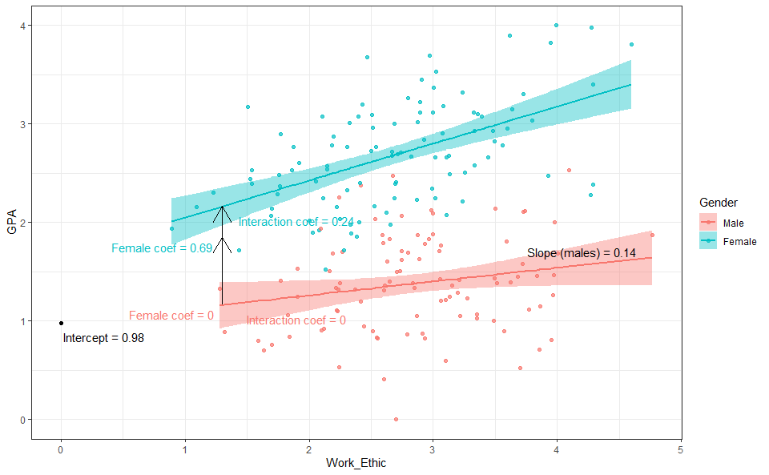

#### A note on centering

In the models above, we didn’t center the continuous predictor Work_ethic. If we had centered it, we would get a slightly different output:

```r
GPA_data <- GPA_data %>%
  mutate(Work_Ethic_centered = scale(Work_Ethic, center = T, scale = F)) # we want to center, but not scale; this could also be done manually by subtracting the mean from all values

GPA.Model.3 <- lm(GPA ~ Work_Ethic_centered * Gender, GPA_data)


summary(GPA.Model.3)
```

[output not shown]

The coefficient for GenderFemale would (again) tell us the difference between genders when Work Ethic = 0. In the previous models, Work Ethic at value 0 wasn’t very meaningful (and in GPA.Model.2, the fitted lines for males and females are very close to each other near the intercept point, hence the smaller and less significant coefficient). Here, however, Work Ethic = 0 represents the mean of Work Ethic (which is 2.78), and the GenderFemale coefficient tells us the difference at that point! So, the coefficient is more easy to interpret.

```r
mean(GPA_data$Work_Ethic)
```

## Custom functions

R allows you to make your own functions to avoid repetitive code - for example for making multiple plots in the same fashion.

Let’s plot the predictions above using a function that takes the linear regression model object as an argument (we’ll leave the annotations out for simplicity).

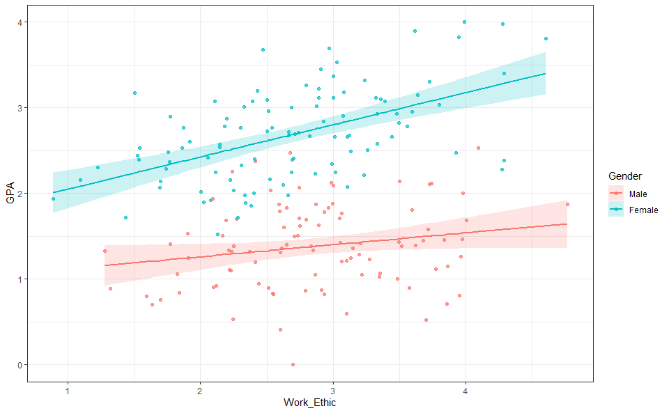

```r
lapply(lm_models, summary)
```

```
[[1]]

Call:
lm(formula = GPA ~ Work_Ethic + Gender, data = GPA_data)

Residuals:
     Min       1Q   Median       3Q      Max
-1.33655 -0.31550  0.00032  0.32895  1.14607

Coefficients:
             Estimate Std. Error t value Pr(>|t|)
(Intercept)   0.60058    0.14171   4.238 3.46e-05 ***
Work_Ethic    0.27275    0.04657   5.857 1.95e-08 ***
GenderFemale  1.35198    0.06788  19.919  < 2e-16 ***
---
Signif. codes:  0 ‘***’ 0.001 ‘**’ 0.01 ‘*’ 0.05 ‘.’ 0.1 ‘ ’ 1

Residual standard error: 0.4765 on 197 degrees of freedom
Multiple R-squared:  0.6752,    Adjusted R-squared:  0.6719
F-statistic: 204.8 on 2 and 197 DF,  p-value: < 2.2e-16


[[2]]

Call:
lm(formula = GPA ~ Work_Ethic * Gender, data = GPA_data)

Residuals:
     Min       1Q   Median       3Q      Max
-1.35807 -0.36015  0.00458  0.32260  1.12149

Coefficients:
                        Estimate Std. Error t value Pr(>|t|)
(Intercept)              0.98106    0.20466   4.794 3.23e-06 ***
Work_Ethic               0.13972    0.06958   2.008  0.04602 *
GenderFemale             0.69482    0.26672   2.605  0.00989 **
Work_Ethic:GenderFemale  0.23580    0.09264   2.545  0.01169 *
---
Signif. codes:  0 ‘***’ 0.001 ‘**’ 0.01 ‘*’ 0.05 ‘.’ 0.1 ‘ ’ 1

Residual standard error: 0.4701 on 196 degrees of freedom
Multiple R-squared:  0.6856,    Adjusted R-squared:  0.6808
F-statistic: 142.5 on 3 and 196 DF,  p-value: < 2.2e-16
```